# 03 AF 10K Ever Gave Classification

# Goal

Differentiate between those who have ever given $10K+ (cash) in a single year and those who haven’t, using the variables deemed most important during [screening](https://github.com/phively/ksm-models/blob/master/af-10k-fy17/02%20AF%2010K%20Variable%20Screening.Rmd).

Cross-validated error will be used to compare modeling approaches. This is not intended to be a *great* model, just a starting point of comparison for later iterations.

# Setup

Load [required packages](https://github.com/phively/ksm-models/blob/master/af-10k-fy17/PACKAGES.txt) and scripts.

For parallelization: set number of workers to ncores - 1.

```r
source('scripts/load_packages.R')
```

```
Read 14 items








foreach: simple, scalable parallel programming from Revolution Analytics
Use Revolution R for scalability, fault tolerance and more.
http://www.revolutionanalytics.com
```

```r
source('scripts/parse_data.R')
registerDoParallel(detectCores() - 1)
```

Generate modeling data.

```r
mdat <- parse_data('data/2017-12-21 AF 10K Model.csv')
```

```
 27237 failed to parse.All formats failed to parse. No formats found.
```

```r
source('scripts/parse_modeling_data.R')
```

# Additional exploration

## Bad model

Throw everything in a GLM.

```r
mbad <- mdat %>%
  glm(GAVE_10K ~ RECORD_STATUS_CODE + ns(RECORD_YR, df = 12) + PROGRAM_GROUP + PREF_ADDR_TYPE_CODE
        + HOUSEHOLD_CONTINENT + BUS_IS_EMPLOYED + HAS_HOME_ADDR + HAS_HOME_PHONE + HAS_HOME_EMAIL
        + GIVING_PLEDGE_ANY + GIVING_PLEDGE_FIRST_YR + ns(GIFTS_ALLOCS_SUPPORTED, df = 1)
        + ns(GIVING_MAX_CASH_YR, df = 3) + ns(GIFTS_CASH, df = 1) + GIFTS_CREDIT_CARD
        + GIFTS_STOCK + ns(GIFT_CLUB_KLC_YRS) + GIFT_CLUB_NU_LDR_YRS + ns(GIFT_CLUB_LOYAL_YRS)
        + VELOCITY_BINS + ns(VELOCITY3_LIN, df = 3)
      , data = .
      , family = binomial)
```

How do predictions vary with `RECORD_YR`?

```r
preds <- predict(mbad, type = 'response', newdata = data.frame(
    RECORD_STATUS_CODE = 'A'
  , RECORD_YR = 1901:2020
  , PROGRAM_GROUP = 'FT'
  , PREF_ADDR_TYPE_CODE = 'HOM'
  , HOUSEHOLD_CONTINENT = 'North America'
  , BUS_IS_EMPLOYED = 'FALSE'
  , HAS_HOME_ADDR = 'FALSE'
  , HAS_HOME_PHONE = 'FALSE'
  , HAS_HOME_EMAIL = 'FALSE'
  , GIVING_PLEDGE_ANY = 'FALSE'
  , GIVING_PLEDGE_FIRST_YR = 'FALSE'
  , GIFTS_ALLOCS_SUPPORTED = mean(mdat$GIFTS_ALLOCS_SUPPORTED)
  , GIFTS_FYS_SUPPORTED = mean(mdat$GIFTS_FYS_SUPPORTED)
  , GIVING_MAX_CASH_YR = mean(mdat$GIVING_MAX_CASH_YR)
  , GIFTS_CASH = mean(mdat$GIFTS_CASH)
  , GIFTS_CREDIT_CARD = '0'
  , GIFTS_STOCK = '0'
  , GIFT_CLUB_KLC_YRS = mean(mdat$GIFT_CLUB_KLC_YRS)
  , GIFT_CLUB_NU_LDR_YRS = '0'
  , GIFT_CLUB_LOYAL_YRS = mean(mdat$GIFT_CLUB_LOYAL_YRS)
  , VELOCITY3 = mean(mdat$VELOCITY3)
  , VELOCITY_BINS = 'A. Non'
  , VELOCITY3_LIN = mean(mdat$VELOCITY3_LIN)
))
```

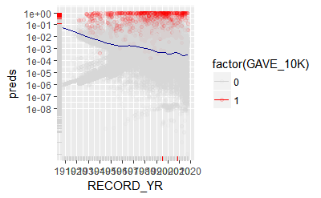

```r
mdat %>% select(GAVE_10K, RECORD_YR) %>% mutate(preds = predict(mbad, type = 'response')) %>%
  left_join(data.frame(RECORD_YR = 1901:2020, expected = preds), by = 'RECORD_YR') %>%
  ggplot(aes(x = RECORD_YR, y = preds, color = factor(GAVE_10K))) +
  geom_point(alpha = .1) +
  geom_line(aes(y = expected), color = 'darkblue') +
  geom_rug() +
  scale_y_log10(breaks = 10^(0:-8)) +
  scale_x_continuous(breaks = seq(1900, 2020, by = 10)) +
  scale_color_manual(values = c('lightgray', 'red'))
```

For a two-class problem the naive decision threshold would be $p \geq 0.5$.

```r
conf_matrix <- function(model, newdata = NULL, threshold = .5) {
  results <- data.frame(
    pred = predict(model, newdata = newdata, type = 'response') >= threshold
  )
  if (is.null(newdata)) {
    results$truth = model$y
  } else {
    results$truth = newdata$GAVE_10K
  }
  results_tbl <- table(truth = results$truth, prediction = results$pred)
  error <- (results_tbl[1, 2] + results_tbl[2, 1]) / sum(results_tbl)
  precision <- results_tbl[2, 2] / sum(results_tbl[, 2])
  sensitivity <- results_tbl[2, 2] / sum(results_tbl[2, ])
  return(
    list(
      # Confusion matrix counts
        conf_matrix = results_tbl
      # Confusion matrix percents
      , conf_matrix_pct = results_tbl / nrow(results)
      # Statistics
      , error = error
      , precision = precision
      , sensitivity = sensitivity
      , F1_score = (precision * sensitivity) / (precision + sensitivity)
    )
  )
}
```

Threshold of 0.5.

```r
conf_matrix(model = mbad, threshold = .5)
```

```
$conf_matrix
     prediction
truth FALSE  TRUE
    0 85079   142
    1   556   457

$conf_matrix_pct
     prediction
truth       FALSE        TRUE
    0 0.986606211 0.001646682
    1 0.006447573 0.005299534

$error
[1] 0.008094255

$precision
[1] 0.7629382

$sensitivity
[1] 0.4511352

$F1_score
[1] 0.2834988
```

The base frequency for `GAVE_10K` is 0.0117.

```r
conf_matrix(model = mbad, threshold = {sum(mdat$GAVE_10K) / nrow(mdat)})
```

```
$conf_matrix
     prediction
truth FALSE  TRUE
    0 79234  5987
    1    55   958

$conf_matrix_pct
     prediction
truth        FALSE         TRUE
    0 0.9188255213 0.0694273720
    1 0.0006377995 0.0111093072

$error
[1] 0.07006517

$precision
[1] 0.137941

$sensitivity
[1] 0.9457058

$F1_score
[1] 0.120382
```

## Train/test split

Begin by creating a holdout sample for testing (10% of the data).

```r
xv <- KFoldXVal(mdat, k = 2, prop = .1, seed = 91471)
holdoutdat <- mdat[xv[[1]], ]
traindat <- mdat[xv[[2]], ]
remove(xv)
```

# Modeling ground rules

- 10-fold cross-validation repeated 5 times.
- Estimate prediction error with out-of-sample classification error.
- $\theta_{1}$ threshold (donor) set to the empirical probability in the cross-validation set (debatable).

```r
# 10-fold cross-validation
folds = 10
# 5 repetitions
reps = 5
```

# Cross-validated logistic regression model

Logistic regression has given good results on similar problems in the past, so I’ll use it for the first approach.

## Baseline model

All explanatory variables with moderate natural spline degrees of freedom.

```r
# Store model errors
errs_glm_baseline <- data.frame(
    reps = rep(1:reps, each = folds)
  , folds = rep(1:folds, times = reps)
  , error = 0
  , precision = 0
  , sensitivity = 0
  , F1_score = 0
)
confus_glm_baseline <- rep(list(NULL), times = reps * folds)
# Seed for reproducibility
set.seed(6469548)
for (rep in 1:reps) {
  # Status report
  paste('+ Iteration', rep, 'beginning at', Sys.time()) %>% print()
  # Create cross-validation indices
  xv <- KFoldXVal(traindat, k = folds)
  for (fold in 1:length(xv)) {
    # Fit temp model
    tmpmodel <- glm(GAVE_10K ~ RECORD_STATUS_CODE
        + ns(RECORD_YR, df = 10)
        + PROGRAM_GROUP + PREF_ADDR_TYPE_CODE + HOUSEHOLD_CONTINENT + BUS_IS_EMPLOYED
        + HAS_HOME_ADDR + HAS_HOME_PHONE + HAS_HOME_EMAIL + GIVING_PLEDGE_ANY
        + GIVING_PLEDGE_FIRST_YR + GIFTS_ALLOCS_SUPPORTED
        + ns(GIVING_MAX_CASH_YR, df = 10)
        + GIFTS_CASH + GIFTS_CREDIT_CARD + GIFTS_STOCK + GIFT_CLUB_KLC_YRS
        + GIFT_CLUB_NU_LDR_YRS + GIFT_CLUB_LOYAL_YRS + VELOCITY_BINS
        + ns(VELOCITY3_LIN, df = 3)
      # Train while withholding some data
      , data = traindat[-xv[[fold]], ]
      , family = binomial) %>% suppressMessages()
    # Prediction threshold
    theta1 <- sum(traindat$GAVE_10K[-xv[[fold]]] == 1) / nrow(traindat[-xv[[fold]], ])
    # Confusion matrix based on the withheld data
    tmpconfus <- conf_matrix(tmpmodel, newdata = traindat[xv[[fold]], ], threshold = theta1)
    # Write results to errors data frame
    errs_glm_baseline <- errs_glm_baseline %>% mutate(
        error = case_when(
            reps == rep & folds == fold ~ tmpconfus$error
          , TRUE ~ error)
      , precision = case_when(
            reps == rep & folds == fold ~ tmpconfus$precision
          , TRUE ~ precision)
      , sensitivity = case_when(
            reps == rep & folds == fold ~ tmpconfus$sensitivity
          , TRUE ~ sensitivity)
      , F1_score = case_when(
            reps == rep & folds == fold ~ tmpconfus$F1_score
          , TRUE ~ F1_score)
    )
    # Write confusion matrix to list
    confus_glm_baseline[[(rep - 1) * folds + fold]] <- tmpconfus$conf_matrix
  }
  # Status report
  paste('-- Iteration', rep, 'ending at', Sys.time()) %>% print()
}
```

```
[1] "+ Iteration 1 beginning at 2018-01-18 13:17:51"
[1] "-- Iteration 1 ending at 2018-01-18 13:19:49"
[1] "+ Iteration 2 beginning at 2018-01-18 13:19:49"
[1] "-- Iteration 2 ending at 2018-01-18 13:21:42"
[1] "+ Iteration 3 beginning at 2018-01-18 13:21:42"
[1] "-- Iteration 3 ending at 2018-01-18 13:23:35"
[1] "+ Iteration 4 beginning at 2018-01-18 13:23:35"
[1] "-- Iteration 4 ending at 2018-01-18 13:25:31"
[1] "+ Iteration 5 beginning at 2018-01-18 13:25:31"
[1] "-- Iteration 5 ending at 2018-01-18 13:27:27"
```

Histograms of results.

```r
histogrammer <- function(errordata, varname, h = .005, fill = 'gray') {
  data.frame(x = errordata[, varname]) %>%
  ggplot(aes(x = x)) +
    geom_histogram(aes(y = ..density..), alpha = .5, binwidth = h, fill = fill) +
    geom_density(alpha = .5) +
    geom_vline(aes(xintercept = mean(x), color = 'mean')) +
    geom_vline(aes(xintercept = median(x), color = 'median'), linetype = 'dashed') +
    labs(x = varname)
}
```

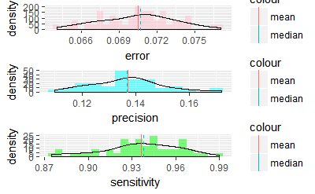

```r
grid.arrange(
    histogrammer(errs_glm_baseline, 'error', h = .0005, fill = 'pink')
  , histogrammer(errs_glm_baseline, 'precision', h = .005, fill = 'cyan')
  , histogrammer(errs_glm_baseline, 'sensitivity', h = .005, fill = 'green')
)
```

The numbers to beat are:

```r
errs_glm_baseline %>% select(error, precision, sensitivity) %>% colMeans() %>% round(4)
```

```
      error   precision sensitivity
     0.0705      0.1370      0.9364
```

## Trimmed model

How does dropping apparently less-useful variables affect cross-validated error?

```r
mbase <- glm(GAVE_10K ~ RECORD_STATUS_CODE
        + ns(RECORD_YR, df = 10)
        + PROGRAM_GROUP + PREF_ADDR_TYPE_CODE + HOUSEHOLD_CONTINENT + BUS_IS_EMPLOYED
        + HAS_HOME_ADDR + HAS_HOME_PHONE + HAS_HOME_EMAIL + GIVING_PLEDGE_ANY
        + GIVING_PLEDGE_FIRST_YR + GIFTS_ALLOCS_SUPPORTED
        + ns(GIVING_MAX_CASH_YR, df = 10)
        + GIFTS_CASH + GIFTS_CREDIT_CARD + GIFTS_STOCK + GIFT_CLUB_KLC_YRS
        + GIFT_CLUB_NU_LDR_YRS + GIFT_CLUB_LOYAL_YRS + VELOCITY_BINS
        + ns(VELOCITY3_LIN, df = 3)
      , data = traindat
      , family = binomial)
```

```
glm.fit: fitted probabilities numerically 0 or 1 occurred
```

```r
summary(mbase)
```

```
Call:
glm(formula = GAVE_10K ~ RECORD_STATUS_CODE + ns(RECORD_YR, df = 10) +
    PROGRAM_GROUP + PREF_ADDR_TYPE_CODE + HOUSEHOLD_CONTINENT +
    BUS_IS_EMPLOYED + HAS_HOME_ADDR + HAS_HOME_PHONE + HAS_HOME_EMAIL +
    GIVING_PLEDGE_ANY + GIVING_PLEDGE_FIRST_YR + GIFTS_ALLOCS_SUPPORTED +
    ns(GIVING_MAX_CASH_YR, df = 10) + GIFTS_CASH + GIFTS_CREDIT_CARD +
    GIFTS_STOCK + GIFT_CLUB_KLC_YRS + GIFT_CLUB_NU_LDR_YRS +
    GIFT_CLUB_LOYAL_YRS + VELOCITY_BINS + ns(VELOCITY3_LIN, df = 3),
    family = binomial, data = traindat)

Deviance Residuals:
    Min       1Q   Median       3Q      Max
-4.0331  -0.0567  -0.0382  -0.0117   4.2193

Coefficients:
                                    Estimate Std. Error z value Pr(>|z|)
(Intercept)                       -1.080e+03  7.099e+02  -1.521 0.128262
RECORD_STATUS_CODEC               -1.427e+00  1.130e+00  -1.263 0.206586
RECORD_STATUS_CODED               -1.639e+00  1.251e+00  -1.310 0.190050
RECORD_STATUS_CODEL               -2.460e+00  1.305e+00  -1.885 0.059420 .
ns(RECORD_YR, df = 10)1           -3.908e+00  8.854e-01  -4.413 1.02e-05 ***
ns(RECORD_YR, df = 10)2           -3.870e+00  1.136e+00  -3.405 0.000661 ***
ns(RECORD_YR, df = 10)3           -4.359e+00  1.007e+00  -4.328 1.50e-05 ***
ns(RECORD_YR, df = 10)4           -5.321e+00  1.079e+00  -4.929 8.25e-07 ***
ns(RECORD_YR, df = 10)5           -4.878e+00  1.051e+00  -4.643 3.44e-06 ***
ns(RECORD_YR, df = 10)6           -5.568e+00  1.105e+00  -5.039 4.69e-07 ***
ns(RECORD_YR, df = 10)7           -4.621e+00  1.116e+00  -4.140 3.48e-05 ***
ns(RECORD_YR, df = 10)8           -5.755e+00  8.941e-01  -6.437 1.22e-10 ***
ns(RECORD_YR, df = 10)9           -8.287e+00  2.243e+00  -3.695 0.000220 ***
ns(RECORD_YR, df = 10)10          -3.385e+00  8.482e-01  -3.991 6.58e-05 ***
PROGRAM_GROUPNONE                  2.350e+00  2.362e-01   9.946  < 2e-16 ***
PROGRAM_GROUPEMP                  -1.955e-01  2.381e-01  -0.821 0.411570
PROGRAM_GROUPEXECED               -6.525e-01  4.709e-01  -1.386 0.165834
PROGRAM_GROUPNONGRD                3.450e-02  6.317e-01   0.055 0.956449
PROGRAM_GROUPPHD                   6.081e-01  5.024e-01   1.210 0.226195
PROGRAM_GROUPTMP                  -2.749e-01  2.174e-01  -1.264 0.206062
PREF_ADDR_TYPE_CODEALT             1.665e+00  1.920e-01   8.673  < 2e-16 ***
PREF_ADDR_TYPE_CODEBUS             7.768e-01  1.691e-01   4.594 4.34e-06 ***
HOUSEHOLD_CONTINENT                2.544e+00  1.294e+00   1.966 0.049311 *
HOUSEHOLD_CONTINENTAfrica          1.065e-01  1.585e+00   0.067 0.946418
```

[output cut: 31 more lines]

```
VELOCITY_BINSE. Unchanged          5.810e-01  3.058e-01   1.900 0.057438 .
VELOCITY_BINSF. Up                -1.239e+01  1.685e+00  -7.353 1.94e-13 ***
ns(VELOCITY3_LIN, df = 3)1        -3.474e+00  3.476e+00  -0.999 0.317581
ns(VELOCITY3_LIN, df = 3)2        -3.609e+01  3.368e+00 -10.716  < 2e-16 ***
ns(VELOCITY3_LIN, df = 3)3         1.913e+01  2.786e+00   6.867 6.55e-12 ***
---
Signif. codes:  0 ‘***’ 0.001 ‘**’ 0.01 ‘*’ 0.05 ‘.’ 0.1 ‘ ’ 1

(Dispersion parameter for binomial family taken to be 1)

    Null deviance: 9963.0  on 77609  degrees of freedom
Residual deviance: 3850.7  on 77550  degrees of freedom
AIC: 3970.7

Number of Fisher Scoring iterations: 20
```

Compare errors dropping `RECORD_STATUS_CODE`, `BUS_IS_EMPLOYED`, `HAS_HOME_ADDR`, `HAS_HOME_PHONE`, `HAS_HOME_EMAIL`.

```r
# Store model errors
errs_glm_trimmed <- data.frame(
    reps = rep(1:reps, each = folds)
  , folds = rep(1:folds, times = reps)
  , error = 0
  , precision = 0
  , sensitivity = 0
  , F1_score = 0
)
confus_glm_trimmed <- rep(list(NULL), times = reps * folds)
# Seed for reproducibility
set.seed(8755737)
for (rep in 1:reps) {
  # Status report
  paste('+ Iteration', rep, 'beginning at', Sys.time()) %>% print()
  # Create cross-validation indices
  xv <- KFoldXVal(traindat, k = folds)
  for (fold in 1:length(xv)) {
    # Fit temp model
    tmpmodel <- glm(GAVE_10K ~
        + ns(RECORD_YR, df = 10)
        + PROGRAM_GROUP + PREF_ADDR_TYPE_CODE + HOUSEHOLD_CONTINENT
        + GIVING_PLEDGE_ANY
        + GIVING_PLEDGE_FIRST_YR + GIFTS_ALLOCS_SUPPORTED
        + ns(GIVING_MAX_CASH_YR, df = 10)
        + GIFTS_CASH + GIFTS_CREDIT_CARD + GIFTS_STOCK + GIFT_CLUB_KLC_YRS
        + GIFT_CLUB_NU_LDR_YRS + GIFT_CLUB_LOYAL_YRS + VELOCITY_BINS
        + ns(VELOCITY3_LIN, df = 3)
      # Train while withholding some data
      , data = traindat[-xv[[fold]], ]
      , family = binomial) %>% suppressMessages()
    # Prediction threshold
    theta1 <- sum(traindat$GAVE_10K[-xv[[fold]]] == 1) / nrow(traindat[-xv[[fold]], ])
    # Confusion matrix based on the withheld data
    tmpconfus <- conf_matrix(tmpmodel, newdata = traindat[xv[[fold]], ], threshold = theta1)
    # Write results to errors data frame
    errs_glm_trimmed <- errs_glm_trimmed %>% mutate(
        error = case_when(
            reps == rep & folds == fold ~ tmpconfus$error
          , TRUE ~ error)
      , precision = case_when(
            reps == rep & folds == fold ~ tmpconfus$precision
          , TRUE ~ precision)
      , sensitivity = case_when(
            reps == rep & folds == fold ~ tmpconfus$sensitivity
          , TRUE ~ sensitivity)
      , F1_score = case_when(
            reps == rep & folds == fold ~ tmpconfus$F1_score
          , TRUE ~ F1_score)
    )
    # Write confusion matrix to list
    confus_glm_trimmed[[(rep - 1) * folds + fold]] <- tmpconfus$conf_matrix
  }
  # Status report
  paste('-- Iteration', rep, 'ending at', Sys.time()) %>% print()
}
```

```
[1] "+ Iteration 1 beginning at 2018-01-18 15:52:49"
[1] "-- Iteration 1 ending at 2018-01-18 15:54:36"
[1] "+ Iteration 2 beginning at 2018-01-18 15:54:36"
[1] "-- Iteration 2 ending at 2018-01-18 15:56:45"
[1] "+ Iteration 3 beginning at 2018-01-18 15:56:45"
[1] "-- Iteration 3 ending at 2018-01-18 15:58:31"
[1] "+ Iteration 4 beginning at 2018-01-18 15:58:31"
[1] "-- Iteration 4 ending at 2018-01-18 16:00:33"
[1] "+ Iteration 5 beginning at 2018-01-18 16:00:33"
[1] "-- Iteration 5 ending at 2018-01-18 16:02:28"
```

```r
data.frame(
    baseline = errs_glm_baseline %>% select(error, precision, sensitivity)
    %>% colMeans() %>% round(4)
  , trimmed = errs_glm_trimmed %>% select(error, precision, sensitivity)
    %>% colMeans() %>% round(4)
)
```

|  | baseline | trimmed |
| --- | --- | --- |
| error | 0.0705 | 0.0703 |
| precision | 0.1370 | 0.1378 |
| sensitivity | 0.9364 | 0.9396 |

This appears to be moving in the right direction.

```r
mtrim <- glm(GAVE_10K ~
        + ns(RECORD_YR, df = 10)
        + PROGRAM_GROUP + PREF_ADDR_TYPE_CODE + HOUSEHOLD_CONTINENT
        + GIVING_PLEDGE_ANY
        + GIVING_PLEDGE_FIRST_YR + GIFTS_ALLOCS_SUPPORTED
        + ns(GIVING_MAX_CASH_YR, df = 10)
        + GIFTS_CASH + GIFTS_CREDIT_CARD + GIFTS_STOCK + GIFT_CLUB_KLC_YRS
        + GIFT_CLUB_NU_LDR_YRS + GIFT_CLUB_LOYAL_YRS + VELOCITY_BINS
        + ns(VELOCITY3_LIN, df = 3)
      , data = traindat
      , family = binomial)
```

```
glm.fit: fitted probabilities numerically 0 or 1 occurred
```

```r
summary(mtrim)
```

```
Call:
glm(formula = GAVE_10K ~ +ns(RECORD_YR, df = 10) + PROGRAM_GROUP +
    PREF_ADDR_TYPE_CODE + HOUSEHOLD_CONTINENT + GIVING_PLEDGE_ANY +
    GIVING_PLEDGE_FIRST_YR + GIFTS_ALLOCS_SUPPORTED + ns(GIVING_MAX_CASH_YR,
    df = 10) + GIFTS_CASH + GIFTS_CREDIT_CARD + GIFTS_STOCK +
    GIFT_CLUB_KLC_YRS + GIFT_CLUB_NU_LDR_YRS + GIFT_CLUB_LOYAL_YRS +
    VELOCITY_BINS + ns(VELOCITY3_LIN, df = 3), family = binomial,
    data = traindat)

Deviance Residuals:
    Min       1Q   Median       3Q      Max
-4.0206  -0.0568  -0.0388  -0.0115   4.2084

Coefficients:
                                    Estimate Std. Error z value Pr(>|z|)
(Intercept)                       -1.084e+03  7.131e+02  -1.520 0.128542
ns(RECORD_YR, df = 10)1           -3.942e+00  8.863e-01  -4.448 8.66e-06 ***
ns(RECORD_YR, df = 10)2           -3.940e+00  1.135e+00  -3.471 0.000518 ***
ns(RECORD_YR, df = 10)3           -4.390e+00  1.002e+00  -4.380 1.18e-05 ***
ns(RECORD_YR, df = 10)4           -5.356e+00  1.075e+00  -4.981 6.32e-07 ***
ns(RECORD_YR, df = 10)5           -4.947e+00  1.047e+00  -4.726 2.30e-06 ***
ns(RECORD_YR, df = 10)6           -5.598e+00  1.100e+00  -5.089 3.60e-07 ***
ns(RECORD_YR, df = 10)7           -4.734e+00  1.113e+00  -4.255 2.09e-05 ***
ns(RECORD_YR, df = 10)8           -5.809e+00  8.859e-01  -6.558 5.46e-11 ***
ns(RECORD_YR, df = 10)9           -8.420e+00  2.247e+00  -3.747 0.000179 ***
ns(RECORD_YR, df = 10)10          -3.642e+00  8.349e-01  -4.362 1.29e-05 ***
PROGRAM_GROUPNONE                  2.355e+00  1.840e-01  12.798  < 2e-16 ***
PROGRAM_GROUPEMP                  -1.882e-01  2.377e-01  -0.792 0.428465
PROGRAM_GROUPEXECED               -6.661e-01  4.664e-01  -1.428 0.153217
PROGRAM_GROUPNONGRD                2.836e-02  6.194e-01   0.046 0.963484
PROGRAM_GROUPPHD                   6.306e-01  4.994e-01   1.263 0.206701
PROGRAM_GROUPTMP                  -2.678e-01  2.168e-01  -1.235 0.216757
PREF_ADDR_TYPE_CODEALT             1.673e+00  1.898e-01   8.817  < 2e-16 ***
PREF_ADDR_TYPE_CODEBUS             7.160e-01  1.601e-01   4.473 7.71e-06 ***
HOUSEHOLD_CONTINENT                4.705e-01  1.391e-01   3.383 0.000717 ***
HOUSEHOLD_CONTINENTAfrica          1.198e-01  1.606e+00   0.075 0.940532
HOUSEHOLD_CONTINENTAsia           -1.651e-01  3.416e-01  -0.483 0.629005
HOUSEHOLD_CONTINENTEurope          6.258e-01  3.396e-01   1.843 0.065383 .
HOUSEHOLD_CONTINENTOceania        -1.520e+01  1.875e+03  -0.008 0.993531
HOUSEHOLD_CONTINENTSouth America  -4.535e-01  9.640e-01  -0.470 0.638060
```

[output cut: 23 more lines]

```
VELOCITY_BINSE. Unchanged          5.835e-01  3.058e-01   1.908 0.056377 .
VELOCITY_BINSF. Up                -1.233e+01  1.671e+00  -7.382 1.56e-13 ***
ns(VELOCITY3_LIN, df = 3)1        -3.615e+00  3.443e+00  -1.050 0.293840
ns(VELOCITY3_LIN, df = 3)2        -3.612e+01  3.360e+00 -10.749  < 2e-16 ***
ns(VELOCITY3_LIN, df = 3)3         1.905e+01  2.763e+00   6.893 5.45e-12 ***
---
Signif. codes:  0 ‘***’ 0.001 ‘**’ 0.01 ‘*’ 0.05 ‘.’ 0.1 ‘ ’ 1

(Dispersion parameter for binomial family taken to be 1)

    Null deviance: 9963.0  on 77609  degrees of freedom
Residual deviance: 3859.9  on 77557  degrees of freedom
AIC: 3965.9

Number of Fisher Scoring iterations: 20
```